# Analiza pracuj.pl

pbi

15 May 2016

```r
library(archivist)
library(ggplot2)

# store everything in the archivist repo
addHooksToPrint(class=c("ggplot"),
                 repoDir = "../arepo",
                 repo = "pracuj", user = "mi2-warsaw", subdir = "arepo")
```

## Pobierz dane

Nalezy najpierw zainstalować pakiet `pracuj` ze strony https://github.com/mi2-warsaw/pracuj/tree/master/pracuj.

```r
library(pracuj)
offers <- get_offers(description = TRUE)
```

## Tylko analitycy (w position jest analyst/analityk)

Wybieramy tylko oferty, które w position mają wpisane Analityk/Analyst.

Z jakich miast są te oferty? Wybieramy 9 najpopularniejszych miast.

```r
library(pracuj)
library(dplyr)
library(ggplot2)

offers %>%
    filter(grepl(position, pattern="(analyst)|(analityk)", ignore.case = TRUE)) ->
    analitycy

dim(analitycy)
```

[1] 3059 10

```r
tt <- table(gsub(gsub(analitycy$location, pattern = " ", replacement = ""), pattern="[,(].*", replacement = ""))[c("Warszawa","Kraków","Poznań","Wrocław","Gdańsk","Łódź","Zabierzów","Katowice","Gdynia")]
df <- data.frame(as.table(tt))
df$Var1 <- reorder(df$Var1, df$Freq, median)

ggplot(df, aes(Var1, fill=Var1, y=Freq)) +scale_fill_discrete(name="") +
  geom_bar(stat="identity") + theme_bw() + xlab("")+ylab("Liczba ofert")+coord_flip() + theme(legend.position="none")
```

Load: [`archivist::aread('mi2-warsaw/pracuj/arepo/fe73da3122ddbca1f3906f112b6214ec')`](https://raw.githubusercontent.com/mi2-warsaw/pracuj/master/arepo/gallery/fe73da3122ddbca1f3906f112b6214ec.rda)

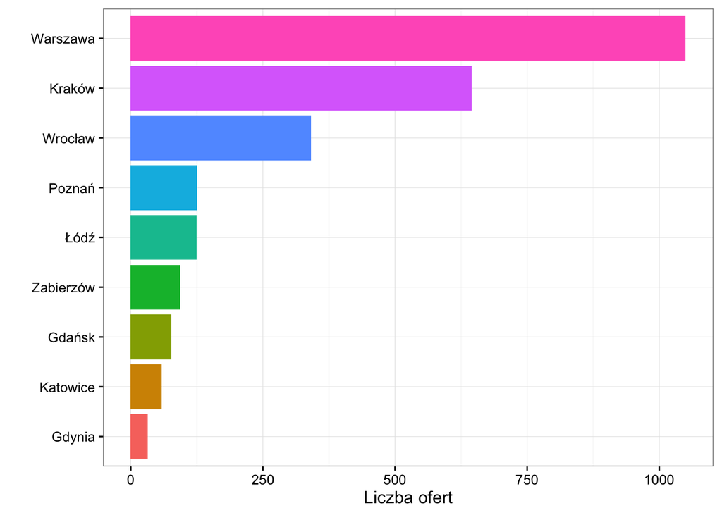

## Chmura słów

Kim są pracodawcy szukający analityków?

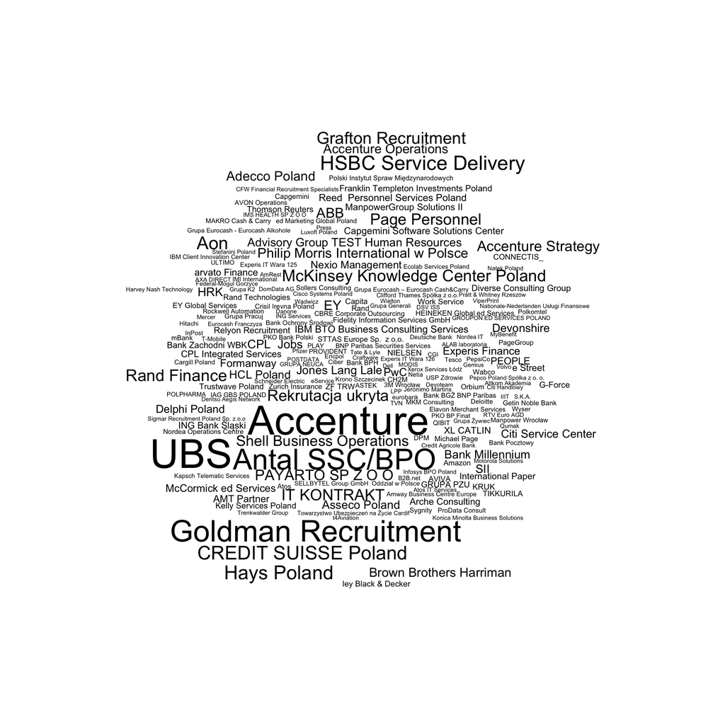

```r
library(wordcloud)
tmp <- analitycy$employer
tmp <- gsub(tmp, pattern = "sp. ?z o. ?o.", replacement = "", ignore.case = TRUE)
tmp <- gsub(tmp, pattern = "polska", replacement = "", ignore.case = TRUE)
tmp <- gsub(tmp, pattern = "s.?a.?", replacement = "", ignore.case = TRUE)
tmp <- gsub(tmp, pattern = ",.*", replacement = "", ignore.case = TRUE)
tmp <- gsub(tmp, pattern = "\\(.*", replacement = "", ignore.case = TRUE)
tmp <- gsub(tmp, pattern = "^ +", replacement = "", ignore.case = TRUE)
tmp <- gsub(tmp, pattern = " +$", replacement = "", ignore.case = TRUE)
pracodawca <- table(tmp)
wordcloud(names(pracodawca), pracodawca, rot.per = 0)
```

## Jakie umiejętności są wymieniane w ofertach pracy?

W ogłoszeniach dla analityków dominuje Excel, na drugim miejscu jest SQL.

Drugi wykres przedstawia umiejętności wymienione po usunięciu tych dwóch najpopularniejszych umiejetności.

```r
dat <- check_frequency(analitycy$description,
            patterns = c( "excel", "[^A-Za-z]SAS", "[^0-9][^0-9A-Za-zóÓ+]R[^0-9A-Za-zóÓęĘśŚćĆ&“”/ö][^&]",
    "big.+data", "data.+mining", "tableau", "SPSS", "stata",
    "cognos", "azure", "machine learning", "spark", "hadoop",
    "matlab", "scikit", "python", "wizualizacj","sql","oracle"),
    case = c( T, T, F, T, T, T, T, T, T, T, T, T, T, T, T, T,
    T, T,T))

dat$tool <- c("Excel", "SAS", "R", "Big Data", "Data Mining",
              "Tableau","SPSS","Stata","Cognos","Azure","Machine Learning","Spark","Hadoop","Matlab","SciKit","Python","Wizualizacja danych","SQL","Oracle")
rownames(dat) <- dat$tool_no <- paste(dat$tool, dat$no)
dat$tool_no <- reorder(dat$tool_no, dat$freq, median)

ggplot(dat, aes(tool_no,no, fill=tool)) +
  geom_bar(stat="identity") +
  coord_flip() + theme_bw() + theme(legend.position="none") +
  ylab("Liczba ofert") + xlab("")
```

Load: [`archivist::aread('mi2-warsaw/pracuj/arepo/b0ca3c790fd3343649d31141a9ef567b')`](https://raw.githubusercontent.com/mi2-warsaw/pracuj/master/arepo/gallery/b0ca3c790fd3343649d31141a9ef567b.rda)

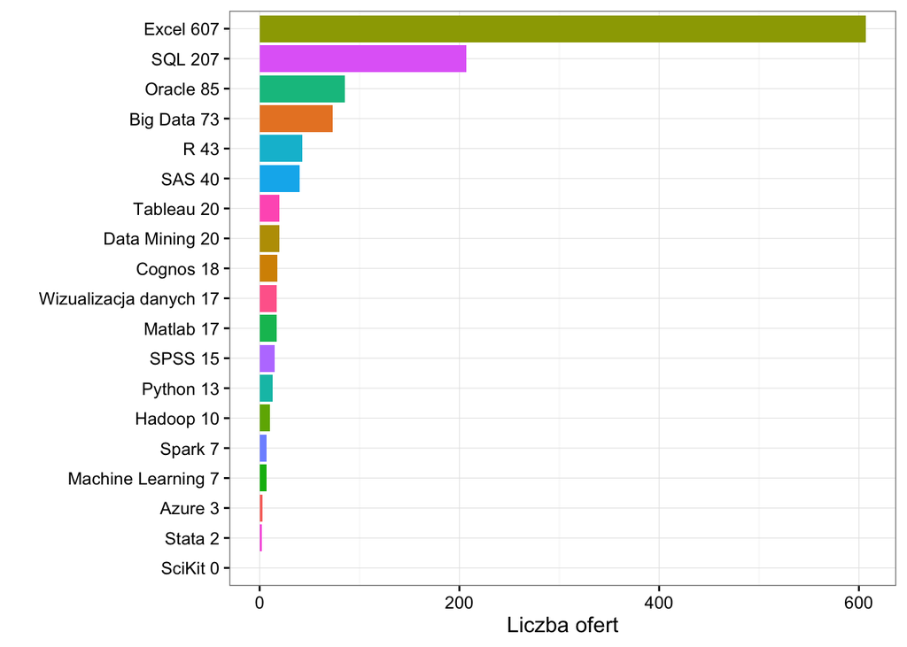

```r
ggplot(dat[c(2:17,19),], aes(tool_no, no)) +
  geom_bar(stat="identity") +
  coord_flip() + theme_bw() + theme(legend.position="none") +
  ylab("Liczba ofert") + xlab("")
```

Load: [`archivist::aread('mi2-warsaw/pracuj/arepo/c65fa251a43f05e77349b0a755a6c278')`](https://raw.githubusercontent.com/mi2-warsaw/pracuj/master/arepo/gallery/c65fa251a43f05e77349b0a755a6c278.rda)

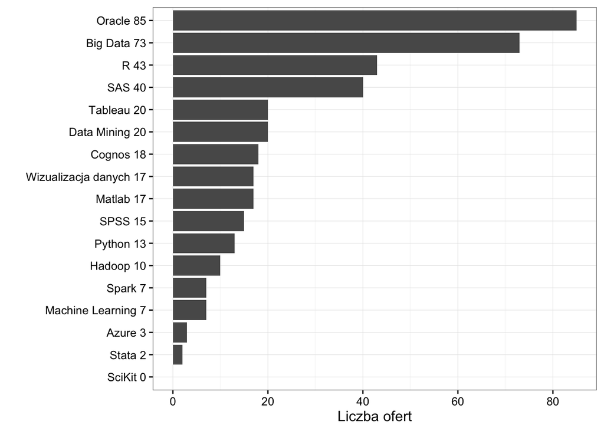

## GitHub

Dane pobrane z pakietem GitHubEr. Dotyczą tylko repozytoriów R użytkowników z lokalizacją określoną na Polskę lub któreś z dużych polskich miast.

Przedstawiamy jaka frakcja użytkowników używa określonych pakietów/funkcji. A następnie pokazujemy jak często dana funkcja/pakiet jest używana.

```r
load("../pracuj/mat.rda")

vv <- colMeans(mat>0)
df <- data.frame(freq=vv, pakiet=names(vv))
df$pakiet <- reorder(df$pakiet, df$freq, mean)

ggplot(df, aes(pakiet, fill=pakiet, y=freq)) +
  geom_bar(stat="identity") + theme_bw() +
  coord_flip() + theme(legend.position="none") +
  scale_y_continuous(labels = scales::percent)+
  xlab("")+ylab("Procent repozytoriów używających pakietu/funkcji [polski github]")
```

Load: [`archivist::aread('mi2-warsaw/pracuj/arepo/60b8089bc1606baac0d54424c2a2ae1c')`](https://raw.githubusercontent.com/mi2-warsaw/pracuj/master/arepo/gallery/60b8089bc1606baac0d54424c2a2ae1c.rda)

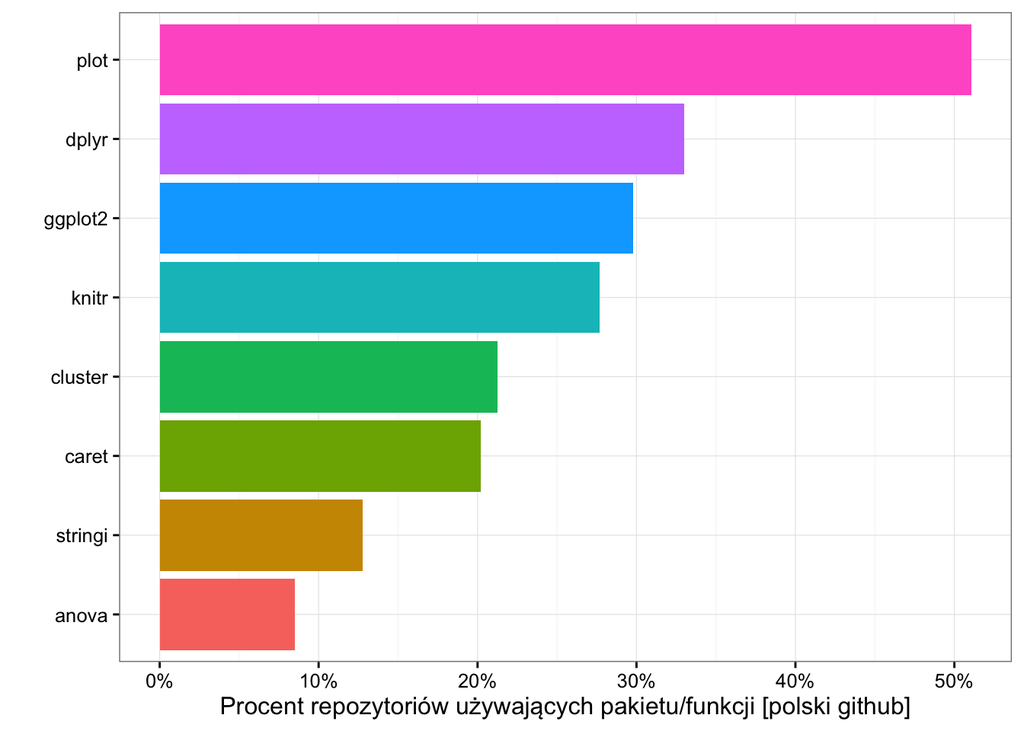

```r
df <- as.data.frame(as.table(mat))
df$Var2 <- reorder(df$Var2, df$Freq, median)
ggplot(df, aes(Var2, fill=Var2, y=Freq)) +
  geom_violin() + theme_bw() +
  coord_flip() + theme(legend.position="none") +
  scale_y_log10(breaks=c(1,2,5,10,20,50,100,200,500,1000,200))+
  xlab("")+ylab("Liczba wywołań określonego pakietu/funkcji [polski github]")
```

Load: [`archivist::aread('mi2-warsaw/pracuj/arepo/ee258e73a9b7e7f687de5a6c0583bc86')`](https://raw.githubusercontent.com/mi2-warsaw/pracuj/master/arepo/gallery/ee258e73a9b7e7f687de5a6c0583bc86.rda)

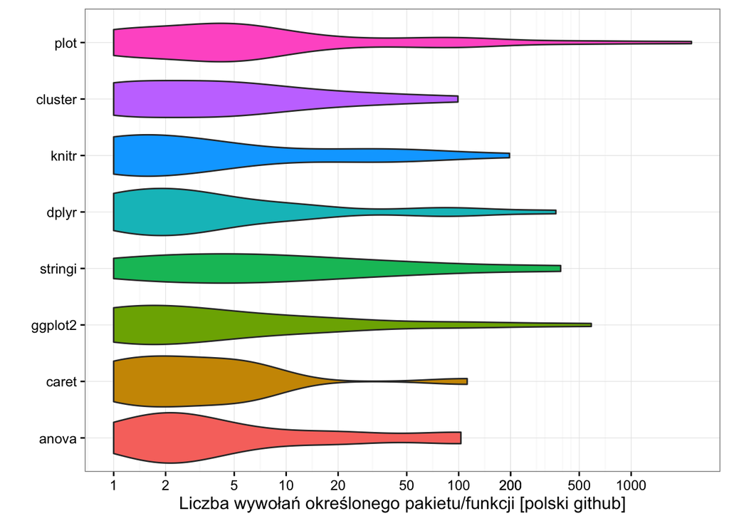

## GitHub - PCA

Analiza składowych głównych.

Nie bierzemy pod uwagę liczby użyć danego pakietu/funkcji a jedynie fakty użycia/nie używania okreslonego narzędzia.

```r
library(ggfortify)
library(ggrepel)
tmp <- prcomp(mat>0)
autoplot(tmp, loadings = TRUE,  loadings.colour = 'blue',
         loadings.label = TRUE, loadings.label.size = 5, label=F,
                 shape=FALSE) + theme_bw() +
    geom_text_repel(data=tmp$x, aes(PC1, PC2, label=rownames(tmp$x)), size=3, alpha=0.8)
```

Load: [`archivist::aread('mi2-warsaw/pracuj/arepo/e98483a4eb16719b4f265996f9971529')`](https://raw.githubusercontent.com/mi2-warsaw/pracuj/master/arepo/gallery/e98483a4eb16719b4f265996f9971529.rda)

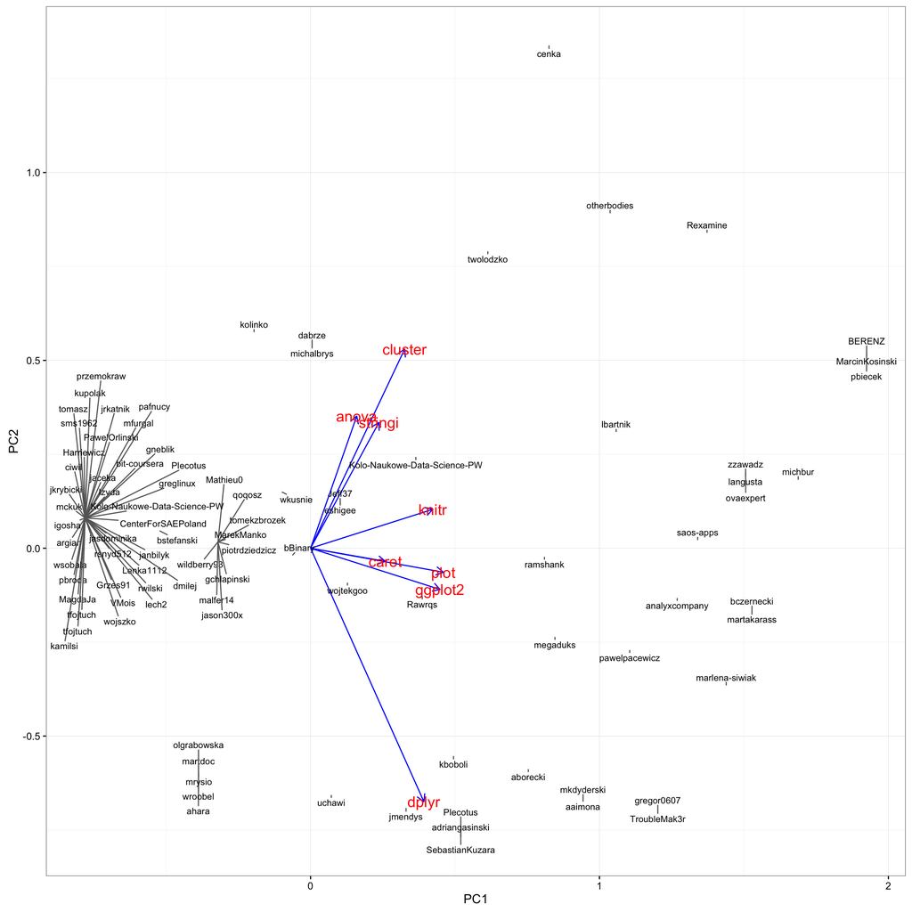